# Regresión Lineal Simple

Javier Cara

Curso 2018-19

# 1 Modelo

Datos:

$(x_i,y_i), i = 1,\ldots,n$

Modelo:

$y_i = \beta_0 + \beta_1 x_i + u_i, \ u_i \sim N(0,\sigma^2)$

Parámetros:

$\beta_0, \beta_1, \sigma^2$

Hipótesis:

- Normalidad: $u_i \sim Normal \Rightarrow y_i \sim Normal$
- Varianza de los datos constante (homocedasticidad): $Var(y_i) = \sigma^2$
- Linealidad: $E(y_i) = \beta_0 + \beta_1 x_i$

# 2 Estimación del modelo

Vamos a utilizar un método que se denomina mínimos cuadrados.

```r
datos = read.csv("Advertising.csv")
str(datos)
```

```
## 'data.frame':    200 obs. of  5 variables:
##  $ X        : int  1 2 3 4 5 6 7 8 9 10 ...
##  $ TV       : num  230.1 44.5 17.2 151.5 180.8 ...
##  $ radio    : num  37.8 39.3 45.9 41.3 10.8 48.9 32.8 19.6 2.1 2.6 ...
##  $ newspaper: num  69.2 45.1 69.3 58.5 58.4 75 23.5 11.6 1 21.2 ...
##  $ sales    : num  22.1 10.4 9.3 18.5 12.9 7.2 11.8 13.2 4.8 10.6 ...
```

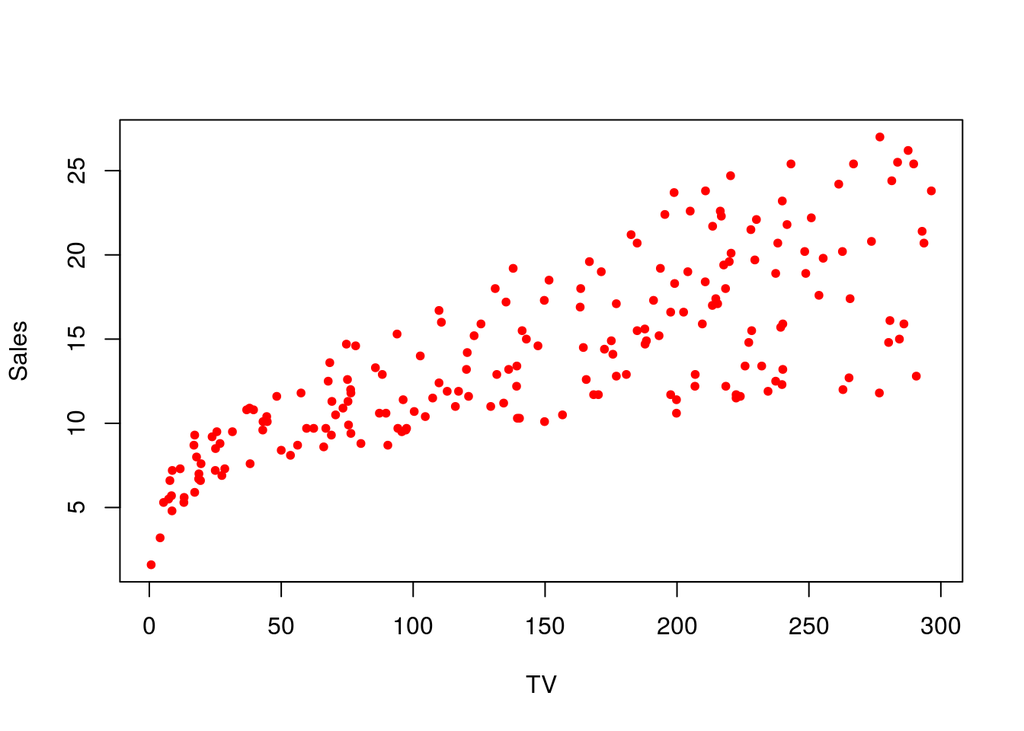

```r
plot(datos$TV, datos$sales, xlab = "TV", ylab = "Sales", col = "red", pch = 20)
```

Se define la *suma de residuos al cuadrado* o *residual sum of squares* (RSS):

$RSS = (y_1 - \hat \beta_0 - \hat \beta_1 x_1)^2 + (y_2 - \hat \beta_0 - \hat \beta_1 x_2)^2 + \cdots + (y_p - \hat \beta_0 - \hat \beta_1 x_p)^2 = \sum \limits _{i=1}^n e_i^2$

El metodo de minimos cuadrados minimiza esta cantidad.

$\frac{\partial RSS}{\partial \hat \beta_1} = 0 \Rightarrow \hat \beta_1 = \frac{\sum _{i=1}^n (x_i - \bar x)(y_i - \bar y)}{\sum _{i=1}^n (x_i - \bar x)^2} = \frac{cov(x,y)}{s_x^2}$

$\frac{\partial RSS}{\partial \hat \beta_0} = 0 \Rightarrow \hat \beta_0 = \bar y - \beta_1 \bar x$

$\hat \sigma ^2 = \frac{\sum _{i=1}^n (y_i - \hat y)^2}{n-2} = \frac{RSS}{n-2}$

Esos parámetros los podemos calcular creando una función:

```r
source("02_funciones.R")
x = datos$TV
y = datos$sales
m1 = rls(y,x)
str(m1)
```

```
## List of 5
##  $ x      : num [1:200] 230.1 44.5 17.2 151.5 180.8 ...
##  $ y      : num [1:200] 22.1 10.4 9.3 18.5 12.9 7.2 11.8 13.2 4.8 10.6 ...
##  $ beta0_e: num 7.03
##  $ beta1_e: num 0.0475
##  $ sigma_e: num 3.26
```

En R se hace:

```r
m2 = lm(y ~ x)
summary(m2)
```

```
##
## Call:
## lm(formula = y ~ x)
##
## Residuals:
##     Min      1Q  Median      3Q     Max
## -8.3860 -1.9545 -0.1913  2.0671  7.2124
##
## Coefficients:
##             Estimate Std. Error t value Pr(>|t|)
## (Intercept) 7.032594   0.457843   15.36   <2e-16 ***
## x           0.047537   0.002691   17.67   <2e-16 ***
## ---
## Signif. codes:  0 '***' 0.001 '**' 0.01 '*' 0.05 '.' 0.1 ' ' 1
##
## Residual standard error: 3.259 on 198 degrees of freedom
## Multiple R-squared:  0.6119, Adjusted R-squared:  0.6099
## F-statistic: 312.1 on 1 and 198 DF,  p-value: < 2.2e-16
```

O también:

```r
m3 = lm(sales ~ TV, data = datos)
summary(m3)
```

```
##
## Call:
## lm(formula = sales ~ TV, data = datos)
##
## Residuals:
##     Min      1Q  Median      3Q     Max
## -8.3860 -1.9545 -0.1913  2.0671  7.2124
##
## Coefficients:
##             Estimate Std. Error t value Pr(>|t|)
## (Intercept) 7.032594   0.457843   15.36   <2e-16 ***
## TV          0.047537   0.002691   17.67   <2e-16 ***
## ---
## Signif. codes:  0 '***' 0.001 '**' 0.01 '*' 0.05 '.' 0.1 ' ' 1
##
## Residual standard error: 3.259 on 198 degrees of freedom
## Multiple R-squared:  0.6119, Adjusted R-squared:  0.6099
## F-statistic: 312.1 on 1 and 198 DF,  p-value: < 2.2e-16
```

Dibujamos la solución:

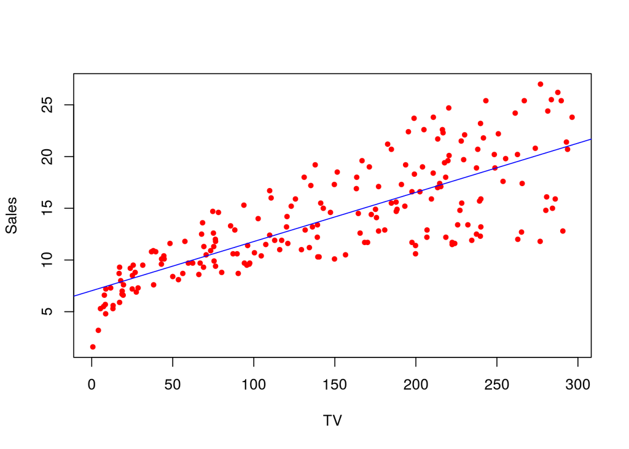

```r
plot(datos$TV, datos$sales, xlab = "TV", ylab = "Sales", col = "red", pch = 20)
abline(m2, col="blue", lwd = 1)
```